# Unutulmuş bir tanrı: Benim sadık yarim kara topraktır

Toprak

Türkçe

Bu yazı, toprağın mitolojik, edebi ve dilbilimsel taraflarını bilimsel perspektifle harmanlayarak ele almaktadır.

Yazar

Bedirhan Avdancı

Yayınlanma Tarihi

20 Nisan 2025

## Unutulmuş bir tanrı: Benim sadık yarim kara topraktır

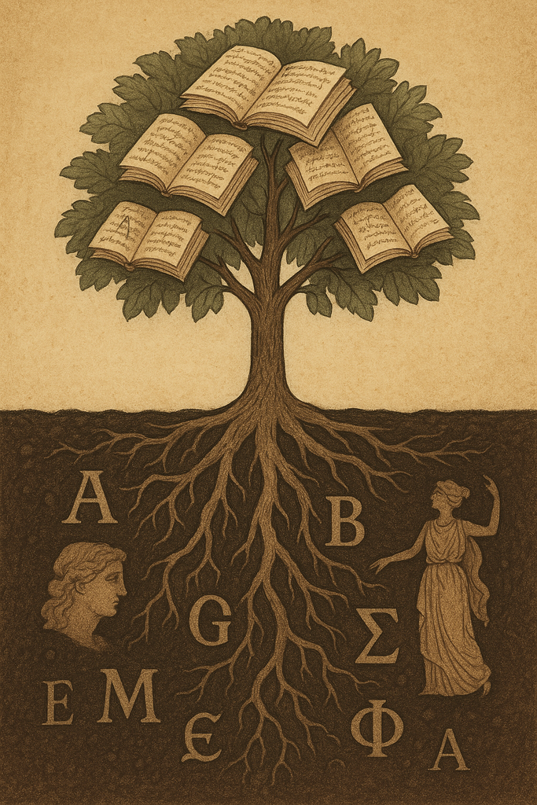

Bu yazıda alışılagelmişin dışına çıkarak, toprak kavramını mitolojik, edebi ve dil bilimsel olarak ele alacağım. Bilindiği üzere toprak, Jeoloji, Biyoloji, Ekoloji, Botanik ve Pedoloji gibi pek çok bilim dalının ilgi alanına giren ve farklı bakış açılarıyla farklı tanımlara bürünen bir kavramdır. Türk Dil Kurumu, toprağı “Yer kabuğunun, toz durumuna gelmiş türlü kütle kırıntılarıyla, çürümüş organik cisimlerden oluşan ve canlılara yaşama ortamı sağlayan yüzey bölümü; kara, yer, hâk, türap” şeklinde tanımlamaktadır. Şahsi olarak toprak kavramı ile biyolojik açıdan ilgilenmem hasebiyle de ilgili tanımın pek de fena olmadığı kanaatindeyim. Lâkin bu tanımı daha isabetli bir hale getirebilmek amacıyla biraz daha genişletmek gerekirse, toprağı “Mineraller, organik materyaller, canlı organizmalar, atmosfer ve suyun birleşimi ile meydana gelen ve tüm bu kavramların bütüncül olarak bir araya gelerek oluşturduğu bir ekosistem” şeklinde tanımlamak daha tutarlı olacaktır. İki tanım arasındaki fark, TDK’nin tanımına göre toprağın “canlılara yaşama ortamı sağlayan yüzey bölümü” olması hasebiyle ekosistemden ziyade bir habitat şeklinde tanımlanmasıdır. Oysaki toprak kavramı, cansız kısmın yanı sıra canlıları da içerisine alan bir ekosistemi temsil etmektedir.

Her ne kadar ben toprağa bilimsel bir perspektiften yaklaşsam da toprağın sosyolojik açıdan da son derece önemli bir yere sahip olduğu gerçeği yadsınamaz bir durumdur. Pek çok farklı mitolojide kutsal bir kavram olarak, hatta çoğu zaman her şeyin başlangıcını sağlayan bir yapıtaşı olarak anılması; bunun yanı sıra destan, masal, ağıt gibi edebi eserlerde yer bulması ve bazı kültürlerde tanrı ya da tanrıça rolüne bürünmesi, bu durumu açıkça kanıtlar niteliktedir.

Toprak, her ne kadar ilgilenilen bilim dalına bağlı olarak farklı niteliklerle tanımlansa da tarih boyunca insanlar için yalnızca biyofiziksel değil; aynı zamanda sosyal, siyasal, ekonomik ve kültürel koşullara göre şekillenmiş çok katmanlı bir anlam alanına sahip olmuştur. Nitekim hemen her kültürde toprak, varoluşun başlangıcını temsil eden bir unsur olarak kabul edilmiştir.

Öyle ki Antik Yunan’da toprak şöyle anlatılır:

> Evren yaratılmadan önce, başlangıçta Kaos denilen bir boşluk vardı. Kaos’tan Gaia, yani toprak meydana geldi. Gaia kendi kendine, kocasız olarak Pontus’u (deniz) ve Uranüs’ü (gök) meydana getirdi. Bundan sonra da Gaia, Eros’un etkisiyle kendinden olma Uranüs ve Pontus ile birleşmiş ve Pontus ile Gaia’nın birleşmesinden Nereus, Thaumas, Phorkys ve Keto doğmuştur. (Aça 2018: 4)

Bu paragrafın beni oldukça etkilediğini söylemeden geçemeyeceğim. Zira şahsi bilgilerimle bu paragraf hakkında yorum yapmam gerekirse, metinde yerkürenin toprak katmanı olarak bahsedilen Gaia kavramının açıkça olmasa bile büyük patlama benzeri bir olay aracılığıyla meydana geldiğinin iddia edildiğini anlamaktayım. İnsanların o dönemki konumunu düşündüğümde, yalnızca akıl yoluyla böyle bir noktaya varılmasının çokça heyecan verici olduğu aşikârdır. Bu doğrultuda, Antik Yunan mitolojisinin bilim denilen kavramı ortaya çıkarmasına pek de şaşmamalı. Fakat elbette yalnızca bu paragraf üzerinden böyle bir çıkarım yapılmasının çok da sağlıklı olmayacağını kabul ediyor ve bu yorumumun yalnızca bir spekülasyon niteliği taşıdığını söylemek istiyorum.

Aynı zamanda Ge (Γῆ) kelimesi Antik Yunan dilinde toprak anlamına gelmektedir. James Lovelock tarafından 1972 yılında önerilen ve günümüzde ekoloji camiasında oldukça geniş ölçekli bir yer bulan, kısaca “Yerkürenin tamamıyla bütün bir şekilde canlı bir organizma gibi davranması” diye tanımlayabileceğimiz Gaia hipotezinin kelime kökeni de böylece toprağa dayanmaktadır. Ge (Γῆ) ya da Gaia aynı zamanda Yunan mitolojisinde en eski ve en güçlü tanrıçalardan biridir ve bir nevi Yunan mitolojisindeki toprak-ana olarak anılmaktadır. Yunan mitolojisine göre Gaia yani toprak ana, mitolojinin en başında evrenin ilk varlığı olarak ortaya çıkmakta ve titanlar, insanlar ve hatta tanrılar olmak üzere tüm varlıkların annesi olarak kabul edilmektedir. Öyle ki Antik Yunan dünyasında, toprağın ve doğanın bereketini sağlamak amacıyla Gaia için birtakım ibadetler de gerçekleştirilmiştir. Bazı mitlerde ise toprak; deniz ve göklerden sonra yaratılmış ve bir nevi tanrı ile insanoğlu arasında bir köprü niteliği görmüş, insanoğlunu oluşturan temel etmen olarak anılmıştır. Öyle ki Altay Yaratılış Destanında toprak:

> Yine bir günlerden bir gün, Tanrı Ülgen denize,  
> Bakarak duruyordu, şaşırdı birdenbire,  
> Bir Toprak parçası, sularda yüzüyordu,  
> Toprağın üzerinde, bir de kil duruyordu  
> Toprak üstündeki şey, dedi, nedir acaba,  
> İnsanoğlu bu olsun, insana olsun baba  
> Görünmeye başladı, insan gibi bir şekil,  
> Birden insan olmuştu, toprak üstündeki kil,  
> İnsanda toplanmıştı, her çeşitten yeterlik,  
> Bu ilk insanın ise, adı olmuştu erlik. (Ögel 1993: 435)

şeklinde bahsedilmiştir.

Bu şiirden anlaşıldığı üzere, toprak Tanrı Ülgen ile ilk insan olan Erlik arasında bir köprü işlevi görmektedir. Altay Yaratılış Destanı’nda toprağın bu şekilde konumlandırılması, onun tüm insanların ham maddesi olarak kabul edilmesine neden olmuştur. Bu bağlamda, toprağa bir kez daha kutsallık atfedildiği görülmektedir.

Bu örneğe oldukça benzer bir biçimde, Semavi dinlerdeki yaratılış anlatılarında da toprağın kutsal bir köken taşıdığı görülür. İlk insan olan Âdem’in adı, İbranice’de “toprak” anlamına gelen adamah kelimesinden türemiştir. Yani, ilk insanın adı doğrudan toprağa işaret etmektedir. Benzer şekilde, Gılgamış Destanı’nda da insanların tanrılar tarafından kil aracılığıyla yaratıldığı ifade edilir. Mezopotamya ve yerli Amerikan mitolojilerinde de insanların toprak ya da kil ile yoğrularak yaratıldığına dair anlatılara sıklıkla rastlanır.

Bu inanış biçimleri öyle güçlü bir etkiye sahip olmuştur ki, insanın bilimsel adı olan Homo sapiens’teki “Homo” (human; insan) kelimesi ile, “canlı materyalin çeşitli fiziksel, kimyasal ve biyolojik süreçler sonucunda ayrışmasıyla oluşan koyu renkli organik toprak” anlamına gelen humus kelimesi etimolojik olarak aynı kökten türetilmiştir. Her iki kelime de Proto-Hint-Avrupa kökenli dhghem- (toprak) sözcük köküne dayanmaktadır. Bu etimolojik bağ, insan ve toprak arasındaki ilişkiyi sadece dilsel düzeyde değil, aynı zamanda kültürel ve düşünsel düzeyde de yansıtarak, insanın doğayla olan derin bağını vurgulamaktadır. İnsanın yaratılışında toprağın önemi Yunus Emre’nin eserlerinde de sıkça yer bulmuştur. Öyle ki Yunus Emre bir eserinde:

> Bir avuç toprak, biraz da suyum ben,  
> Neyimle övüneyim, işte buyum ben.

Dizeleriyle insanın toprak ve sudan oluştuğunu vurgulamanın yanı sıra, “Neyimle övüneyim, işte buyum ben.” kısmında ise bir alçakgönüllülük söz konusudur ki yazının ileri kısımlarında bu konuya özel olarak değinilmiştir.

Bu durumu bilimsel açıdan değerlendirdiğimizde, karasal habitatlarda yaşayan canlıların—ve dolayısıyla bu canlı gruplarından biri olan insanoğlunun—toprağa son derece bağlı olduğu açıkça görülmektedir. Bu bağlamda, edebi metinlerde ve mitolojik anlatılarda toprağa atfedilen kutsallığı, biyolojik bir gerçekliğe dayandırmak yanlış olmayacaktır. Nitekim karasal ekosistemlerdeki besin ağı, yaşamlarını toprakta sürdüren ve ototrof görevini üstlenen bitkilerle başlar. Bitkiler, güneş enerjisini kullanarak sentezledikleri besin maddelerinin ve yapı taşlarının büyük bir bölümünü topraktan elde ederler (bazı temel elementleri—örneğin hidrojen, oksijen ve karbon—toprağın yanı sıra doğrudan atmosferden de alabilirler). Öte yandan, bu besin maddeleri, organizmaların ölümünden sonra çürükçül canlılar tarafından ayrıştırılarak yeniden toprağa kazandırılır. Bu döngü göz önüne alındığında, toprak karasal yaşam için hem doğumun hem de ölümün temsilcisi hâline gelmektedir. Dolayısıyla, insanoğlu da dâhil olmak üzere tüm karasal canlılar açısından toprak, hayati öneme sahip bir unsurdur.

Toprak, edebi bağlamda yalnızca doğum ve yaratılışla değil, aynı zamanda ölümle de ilişkilendirilmiştir. Daha önce de değinildiği gibi, ölüm karasal canlıların yaşamsal işlevlerini yitirip, çeşitli biyolojik süreçler sonucunda moleküllerine ayrışarak toprağa karışması—yani toprağa geri dönmesi—anlamına gelir. Bu ayrışma süreci diğer canlılar için olduğu gibi insanlar için de geçerlidir. İnsanlarda ise bu süreç, ölülerin toprağa gömülmesi şeklinde gerçekleşir; ayrışma, gömülmenin ardından toprak altında devam eder. Bu yönüyle toprak, yaşamını yitirmiş insanlar için bir “son konaklama yeri” işlevi görür. Aynı zamanda, insanın geldiği yere—yani toprağa—yeniden dönmesi anlamını da taşır. Pek çok inanç sistemine göre ölüm, nihai bir son değil; aksine tanrıya ya da ilahi olana yeniden kavuşma olarak yorumlanır. Bu bağlamda toprak, yaratılışta tanrı ile insan arasında bir aracı rolü üstlendiği gibi, ölümün ardından da insanın tanrıya kavuşmasında bir köprü vazifesi görür. Toprağın bu yönü, çeşitli edebi metinlerde de yer bulmuştur. Nitekim Yunus Emre, toprağın ölümle olan ilişkisini şu dizelerinde açıkça dile getirir:

> Cânum bu tene gireli nazarum yokdur altûna  
> Düşdüm ayaklar altına topraklayın tozar oldum

> (Canım bu tene gireli değerli madenlere ilgim yoktur;  
> Ayaklar altına düştüm, toprak gibi tozuyorum.)

Burada Yunus Emre, ölümü “toprak gibi tozar olmak” şeklinde tanımlar. Bu ifade, insanın ölümden sonra toprağa karışarak onun bir parçası haline gelmesini hem mecazi hem de fiziksel bir dönüşüm olarak yansıtır.

Türkçe Sözlükte toz kelimesi ile töz kelimesi eş değer haldedir. Tanımı ise “Çok küçük ve hafif parçacıklara bölünmüş toprak, çok küçük parçacıklara bölünmüş olan herhangi bir madde, toz durumunda olan.” şeklinde yapılmıştır. Dolayısıyla Yunus Emre, ilgili dizelerinde, insanın öldükten sonra toprağa gömülmesi ile her bir zerresinin toprağa karışacağını vurgulamak istemiş olabilir.

Aynı zamanda Yunus Emre farklı bir beytinde ise topraktan:

> Birgün ola sensüz kalam  
> Kurda kuşa ögün olam  
> Çürüyüben toprak olam  
> Âh n’ideyin ’ömrüm seni (M-384/7)

> (Birgün olsun sensiz kalayım  
> Kurda kuşa öğün olayım  
> Çürüyeyim toprak olayım  
> Ah ne yapayım ömrüm seni)

Şeklinde bahsetmiştir.

Bu beyti yorumlamak gerekirse, “Şayet sensiz kalırsam, kurda kuşa yem olurum, çürüyüp toprak olurum” şeklinde bir yakarış söz konusudur. Burada “Kurda kuşa yem olmak” ve “Çürüyüp toprak olmak” dizelerindeki kasıt muhtemelen ölmektir. Hasılı, öldükten sonra toprağa geri dönüş inancı bu edebi eserde de olduğu gibi sıkça yer almaktadır.

Daha önce de değindiğim gibi, toprak ile alçakgönüllülük arasında güçlü bir ilişki vardır. Öyle ki, İngilizcede “alçakgönüllülük” anlamına gelen humility kelimesi, Latince’de “toprak” anlamına gelen humus kelimesinden türemiştir. Bu durum, human (insan) ve homo (insanoğlu) gibi kelimelerle aynı kökten geliyor oluşuyla da dikkat çekicidir. Alçakgönüllülük, kelime anlamı itibarıyla “yükseklerde olmamak” ya da “yere yakın olmak” fikriyle ilişkilidir. Buradaki “yer”, büyük olasılıkla toprak anlamına gelir. Bu sembolik ilişkiyi tam olarak kavrayabilmek için, gerek Ural-Altay mitolojilerinde gerekse Semavi dinlerde yer alan toprak ve tanrı kavramlarını bilmek faydalı olacaktır. Birçok gelenekte gök, tanrısal olanla; yer ise insanla özdeşleştirilmiştir. Bu çerçevede, humility kelimesinin ima ettiği “yere yakınlık”, kişinin haddini bilmesi, kendi yerini tanıması ve tanrısal iddialarda bulunmaması anlamına gelir. Yani bu, varoluşta kendi sınırlarını kabullenmenin ve benliği törpülemenin dilsel bir ifadesidir. Öte yandan, toprağa dönmek —ölüm anında olduğu gibi— insanın nihai olarak egosunu terk etmesi, benlikten sıyrılmasıdır. Humility de bu anlamda bir tür egosuzluk, bir içsel arınma hâlidir. Tasavvuf geleneğinde de alçakgönüllülük, yere bakmak, yere kapanmak gibi imgelerle ifade edilir. Mevlânâ’nın “Toprak gibi ol” öğüdü, bu anlayışın güçlü bir sembolüdür.

Toprak kavramı, geçmiş dönem mitlerinde ve edebi eserlerinde olduğu gibi, modern dönem edebiyatında da önemli bir yer tutmaya devam etmiştir. Bu bağlamda, en bilinen örneklerden biri Aşık Veysel’in “Benim Sadık Yârim Kara Topraktır” adlı eseridir. Söz konusu eser, ilk olarak bir şiir olarak kaleme alınmış olup 11’li hece ölçüsüyle yazılmıştır. Halk şiiri geleneğinde yaygın olarak kullanılan 11, 8 veya 7’li hece ölçüsü, Aşık Veysel’in bu geleneğe olan bağlılığını yansıtmaktadır. Bu ölçülerin tercih edilme sebeplerinden biri, ahenkli yapıları sayesinde kolayca ezberlenebilir olmalarıdır. Zira halk şiiri geleneğinde şiirlerin genellikle sözlü biçimde aktarılması, ezberlenebilirliği önemli kılan temel etkenlerden biridir.

Ayrıca, kırsal bölgelerde bestelenip bağlama eşliğinde söylenen şiirlerde ritim unsuru büyük bir öneme sahiptir. Hece ölçüsü ise bu ritmi sağlayan temel yapı taşlarından biridir. Aşık Veysel, bir halk ozanı olması sebebiyle eserlerini çoğunlukla bağlama eşliğinde seslendirmiştir. Bu nedenle, “Benim Sadık Yârim Kara Topraktır” hem şiir hem de türkü formunda değerlendirilmektedir.

Eserin tam olarak ne zaman yazıldığı kesin olmamakla birlikte, 1940’lı yıllarda kaleme alındığı düşünülmektedir. Nitekim şiir, ilk kez 1948 yılında yayımlanan Deyişler adlı kitapta yer almış; bu da eserin bu tarihten önce yazıldığını göstermektedir.

Sözleri:

> Benim Sadık Yârim Kara Topraktır

> Dost dost diye nicesine sarıldım  
> Benim sadık yârim kara topraktır  
> Beyhude dolandım, boşa yoruldum  
> Benim sadık yârim kara topraktır

> Nice güzellere bağlandım kaldım  
> Ne bir vefa gördüm ne fayda buldum  
> Her türlü isteğim topraktan aldım  
> Benim sadık yârim kara topraktır

> Koyun verdi, kuzu verdi, süt verdi  
> Yemek verdi, ekmek verdi, et verdi  
> Kazma ile döğmeyince kıt verdi  
> Benim sadık yârim kara topraktır

> Bütün kusurumu toprak gizliyor  
> Merhem çalıp yaralarımı sızlıyor  
> Kolun açmış yollarımı gözlüyor  
> Benim sadık yârim kara topraktır

> Güzel bu sözleri eğri büğrü etme  
> Bunda karar kıl, başka türlü gitme  
> Her kim ki olursa bu sırra yetme  
> Benim sadık yârim kara topraktır

Burada Aşık Veysel’in vermek istediği en temel mesaj toprağın hem bir başlangıç hem de bir son olduğu düşüncesidir. Öyle ki:

Toprak Doğurur: “Koyun verdi, kuzu verdi, süt verdi…”  
Toprak Doyurur: “Yemek verdi, ekmek verdi…”  
Toprak Gizler ve Saklar: “Bütün kusurumu toprak gizliyor…”  
Toprak Nihayetinde Sığınılan Yerdir: “Benim sadık yârim kara topraktır.”  
Toprak Bir Sondur: “Kolun açmış yollarımı gözlüyor.”

Bu doğrultuda toprak, yalnızca fiziksel bir madde olarak değil; yoldaşlık eden, annelik yapan, besleyen ve bağışlayan bir figür olarak ele alınmıştır. Bu yaklaşım, özellikle kırsal kesimde yaşayan insanların toprakla kurduğu derin ve iç içe geçmiş ilişkiyi başarılı bir biçimde yansıtır. Bunun yanı sıra, şiirde geçen “Kazma ile döğmeyince kıt verdi” mısrası, toprağın bu cömertliğini karşılıksız yapmadığını, emeğe dayalı bir ilişki kurduğunu ifade eder. Bu durum yalnızca halk arasında yaygın olan “emeksiz yemek olmaz” atasözüyle değil, aynı zamanda İslam’daki tevekkül anlayışıyla da paralellik gösterir. Nitekim “Önce deveni bağla, sonra tevekkül et” (Tirmizî, Sıfatü’l-Kıyâme, 60) hadisi, kişinin önce çabasını göstermesi gerektiğini, ardından teslimiyetin anlam kazandığını vurgular. Her ne kadar spekülatif olsa da “Toprak Ana” kavramı gibi verimlilik ve bereketle ilişkilendirilen tanrıça figürlerinden doğan “emeksiz yemek olmaz” anlayışının, zamanla gelişen inanışlarla birlikte modern Tanrı kavramına da uygulanması, tevekkül düşüncesinin kökenine dair ilginç bir yorum sunabilir.

İnanç, insanın tarih sahnesine çıktığı ilk anlardan itibaren, evrimsel psikolojik süreçler içerisinde adeta zaruri bir ihtiyaç halini almıştır. Bu durumun birkaç tartışmalı nedeni bulunmaktadır. Bunlardan ilki; diğer hayvanlara kıyasla daha zeki olan insanın, o dönemin koşullarında anlam veremediği doğa olaylarına karşı bir açıklama arayışı içerisinde olması ve bu doğrultuda, olayları anlamlandırmak adına zihinsel kısa yollar ya da simgesel anlamlar geliştirmiş olmasıdır. İkinci neden ise; sosyal yaşam içinde, bireyin psikolojik olarak rahatlamasını ve kendini güvende hissetmesini sağlayan bir tanrıya veya tanrıçaya inanma eğilimidir—yani, her koşulda insanı koruyup gözeten yüce bir varlığın varlığına duyulan inanç. Bu düşünme biçimi, günümüzde de pek çok toplum tarafından sürdürülmekte olup, insanın inanma ihtiyacına dair önemli bir kanıt olarak değerlendirilebilir. Buna ek olarak, inançsız bireylerden oluşan topluluklar arasında da bazı alternatif inanç sistemlerine (örneğin fal, astroloji, karma ya da belirli sayılara anlam yükleme gibi) yönelimin oldukça yaygın olması, bu ihtiyacın modern yansımalarından biri olarak gösterilebilir. Aşık Veysel’in “Benim sadık yârim kara topraktır” mısrasında, “İnsanın sosyal yaşam içinde, bireyin psikolojik olarak rahatlamasını ve kendini güvende hissetmesini sağlayan bir tanrıya veya tanrıçaya inanma eğilimi” arasında bir analoji kurmak mümkündür. Şiirinde toprak, ne olursa olsun Aşık Veysel’in yanında olan ve ona destek veren bir figür olarak tasvir edilmiştir. Bu da daha önce bahsettiğim gibi, insanın inanç geliştirme gereksinimlerinden biri olarak karşımıza çıkar. Bu bakımdan, toprak, unutulmuş bir tanrı olmasına rağmen, tanrı ya da tanrıça sıfatlarını henüz kaybetmiş değildir.

Son olarak, toprak kavramını, son derece değerli bulduğum Alevi-Bektaşi felsefesi bağlamında değerlendirmek isterim. Alevi-Bektaşi öğretisinde doğa kutsaldır, çünkü Tanrı (Hak) doğada, taşta, ağaçta, suda ve özellikle toprakta tecelli eder. Bu anlayışa göre toprak yalnızca bir madde değil, Tanrı’nın bir yansımasıdır. Aşık Veysel’in şiirinde toprak bir yâr gibi konuşulur; ancak bu yâr, cansız değildir, uzak değildir, vefasız hiç değildir. Bu, Alevi-Bektaşi düşüncesindeki “Enel Hak” (Ben Hakk’ım) ilkesinin ve doğada Tanrı’yı görme anlayışının bir yansımasıdır. Toprak burada mecaz değil, gerçek bir varlık, bir yoldaş, hatta bir mürşit (öğretmen) gibidir.

Alevi geleneğinde doğurganlık, besleyicilik ve bağışlayıcılık gibi nitelikler dişil enerjiyi temsil eder. Bu bağlamda “Toprak Ana” hayat veren (Ana), acıyı saklayan (Sabırlı) ve herkese eşit davranan (Adaletli) bir figürdür. Aşık Veysel’in toprağı bu şekilde betimlemesi, aslında Toprak Ana’ya bir deyiş söylediğini düşündürebilir. Örneğin:

• “Koyun verdi, kuzu verdi, süt verdi…”  
• “Yemek verdi, ekmek verdi…”

Bu noktada Veysel’in şiiri, bir cem ayininde okunan nefesler gibi, doğayı kutsayan bir dua niteliği kazanır. “Benim sadık yârim kara topraktır” mısrası, Alevi felsefesinde nefsin eğitilmesi ve benliğin toprağa dönüşerek yok olması düşüncesiyle birebir örtüşür. Veysel’in bu satırı, bir Alevi dervişinin “benliğini toprağa vererek Hakk’a ulaşma” arzusunu yansıtır gibidir.

Bu anlayışa göre:

• İnsan toprağa dönmelidir çünkü kibir, ego, mal-mülk gelip geçicidir.  
• Toprak ise sabit, sessiz ve bilgedir.  
• Dolayısıyla “sadık yâr” dünya değil, topraktır — çünkü o insanın hem özüdür hem de varacağı yerdir.

Alevilikte ölüm yoktur, dönüş vardır: İnsan toprağa döner, doğa döner, evren döner. Bu şiirde de bu döngü çok güçlüdür. Bu yönüyle şiir hem bir aşkla yazılmış deyiş hem de bir doğayla barışmış dervişin hikmeti gibi okunabilir.

Pir Sultan Abdal, bir eserinde topraktan (turâb) şöyle bahsetmiştir:

> Pîr Sultan’ım, eydür okur yazarım  
> Turâb olup ayaklarda tozarım  
> Ezelden içmişim, sermest gezerim  
> Pîrden içilmeyen doluyu neylersin?

Bu dizelerde toprağın yerde olması ve çiğnenmesi, tevazuyu simgeler. Bu bağlamda, mısralar, Alevi-Bektaşi felsefesinde toprağın alçakgönüllülüğünü ve konumunun derin anlamını vurgular niteliktedir.

### Öneriler

“Kara Toprak” eseri, başta Aşık Veysel (Veysel Satıroğlu) olmak üzere birçok sanatçı tarafından farklı tarzlarda yorumlanmıştır. Her bir yorum, eserin ruhunu farklı bir açıdan yansıtır. Benim favorim, şüphesiz Aşık Veysel’in 1969 yılında yaptığı canlı performanstır. Bununla birlikte, farklı müzikal yaklaşımlarla seslendirilen birçok değerli versiyon da mevcuttur.

Aşağıda, bu eserin öne çıkan bazı yorumlarını ve önerdiğim versiyonları bulabilirsiniz:

**[Aşık Veysel – Kara Toprak (Canlı Performans, 1969)](https://www.youtube.com/watch?v=BwAjsvfRbTY&pp=ygULa2FyYSB0b3ByYWs%3D)**  
Eserin otantik ve en dokunaklı versiyonlarından biri.

**[Fazıl Say – Kara Toprak (Piyano Yorumu)](https://www.youtube.com/watch?v=KG9wifgWdAQ&pp=ygULa2FyYSB0b3ByYWs%3D)**  
Klasik batı müziği ile Türk halk ezgilerini birleştiren çağdaş ve etkileyici bir yorum.

**[Haluk Levent & Ziliia Shumilina – Kara Toprak (Folk-Rock Yorumu)](https://www.youtube.com/watch?v=J4dP2QOv41E&pp=ygUYaGFsdWsgbGV2ZW50IGthcmEgdG9wcmFr)**  
Blues etkili folk-rock tarzında, modern dokunuşlar içeren güçlü bir performans.

### Kaynakça

Özcan, H. (2001). BEKTÂŞÎ ÂDÂB VE ERKÂNI. Türk Kültürü ve Hacı Bektaş Veli Araştırma Dergisi, (19).

Wall, D. H. (Ed.). (2012). Soil ecology and ecosystem services. Oxford University Press. https://doi.org/10.1093/acprof:oso/9780199575923.001.0001

Albayrak, K. (2019). Yunus Emre Divanı’nda toprak unsurunun Türk mitolojisi açısından değerlendirilmesi / Evaluation of soil concept in the diwan of Yunus Emre in terms of Turkish mythology (Yüksek lisans tezi, Bolu Abant İzzet Baysal Üniversitesi, Sosyal Bilimler Enstitüsü). Bolu Abant İzzet Baysal Üniversitesi.,

Yıldırım, A. (2023). Âşık Veysel’in “Kara Toprak” şiirini aksiyolojik yönden inceleme. RumeliDE Dil ve Edebiyat Araştırmaları Dergisi, (36), 533–540. https://doi.org/10.29000/rumelide.1369101

Bal, S. (2024). Türkiye Türkçesi ağızlarında toprak kavramı ve kavram alanı / Soil concept and its conceptual field in Turkish dialects (Doktora tezi, Sakarya Üniversitesi, Sosyal Bilimler Enstitüsü). Sakarya Üniversitesi.